# Introducción a distribuciones de probabilidad

Ramon Ceballos

7/2/2021

# **Distribución de Poisson**

## 1. Conceptos teóricos y matemáticos

Si **$X$** es variable aleatoria de Poisson con parámetro lambda cuando la variable aleatoria mide el “número de eventos que ocurren en un cierto intervalo de tiempo”, diremos que **$X$** se distribuye como una Poisson con parámetro **$\lambda$**. La **$\lambda$** de la distribución de Poisson represente el nº de veces que se espera que ocurra el evento durante un intervalo de tiempo dado (o cualquier otra unidad de medida).

$$X\sim \text{Po}(\lambda)$$

donde **$\lambda$** representa el número de veces que se espera que ocurra el evento durante un intervalo dado.

Vamos a definir algunas de las propiedades que tendrá una distribución Poisson.

- El **dominio** de $X$ será $D_X = \{0,1,2,\dots\}$. Siguen siendo los nºs naturales.
- La **función de probabilidad** vendrá dada por:
  $$f(k) = \frac{e^{-\lambda}\lambda^k}{k!}$$

De este modo, cuando k tiende a infinito la probabilidad del suceso tenderá a cero.

- La **función de distribución** vendrá dada por
  $$F(x) = \left\{
  \begin{array}{cl}
  0 & \text{si } x<0
  \\ \sum_{k=0}^xf(k) & \text{si } 0\le x<n
  \\ 1 & \text{si } x\ge n
  \end{array}
  \right.$$
- **Esperanza**. $E(X) = \lambda$.
- **Varianza**. $Var(X) = \lambda$.

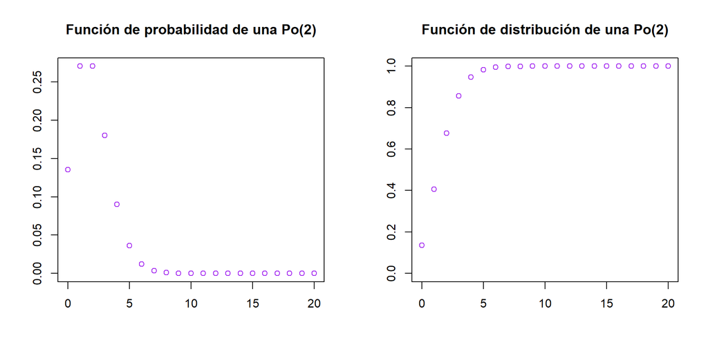

```r
par(mfrow = c(1,2))

#Distr. Poisson de parámetro 2
#La lambda es 2
plot(0:20, dpois(0:20,2),
     col = "purple", xlab = "",
     ylab = "",
     main = "Función de probabilidad de una Po(2)")

plot(0:20, ppois(0:20,2),col = "purple",
     xlab = "", ylab = "",
     main = "Función de distribución de una Po(2)",
     ylim = c(0,1))
```

```r
par(mfrow= c(1,1))
```

Ejemplos: nºs de personas que entran en una tienda cada cierta unidad de tiempo (sería la frecuencia por unidad de medida); los errores de una página (unidad de medida son los errores por página).

## 2. Distribución de Poisson en `R` y `Python`

El código de la distribución de Poisson:

- En **`R`** tenemos las funciones del paquete `Rlab`: **`dpois(x, lambda), ppois(q,lambda), qpois(p,lambda), rpois(n, lambda)`** donde `lambda` es el número esperado de eventos por unidad de tiempo de la distribución.
- En `Python` tenemos las funciones del paquete **`scipy.stats.poisson`**: **`pmf(k,mu), cdf(k,mu), ppf(q,mu), rvs(M,mu)`** donde `mu` es el número esperado de eventos por unidad de tiempo de la distribución.

## 3. Ejemplos en código para la distribución de Poisson (R y Python)

Supongamos que **$X$** modela el número de errores por página que tiene un valor esperado **$\lambda = 5$** de errores.

#### **Ejemplo en R**

Empleamos las funciones anteriores.

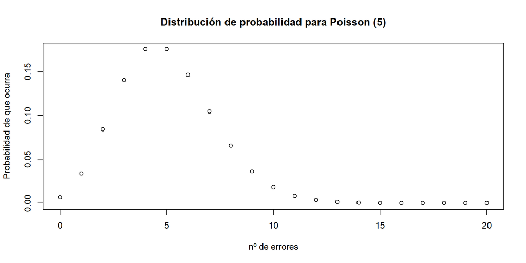

```r
#defino la lambda
l = 5

#Defino la distribución de probabilidad para Poisson (5)
plot(0:20, dpois(x = 0:20, lambda = l),
     title("Distribución de probabilidad para Poisson (5)"),
     xlab = "nº de errores",
     ylab = "Probabilidad de que ocurra")
```

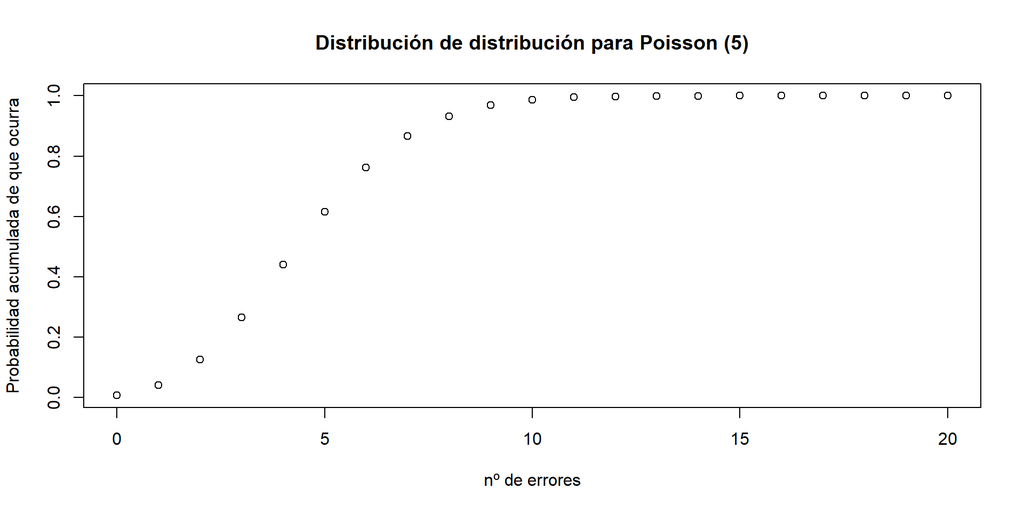

```r
#Defino la distribución de distribución para Poisson (5)
plot(0:20,ppois(0:20, l),
     title("Distribución de distribución para Poisson (5)"),
     xlab = "nº de errores",
     ylab = "Probabilidad acumulada de que ocurra")
```

```r
#La mediana
qpois(0.5, 5)
```

```
## [1] 5
```

[figure not shown]

```r
#Genero datos aleatorios con Poisson
rpois(1000, lambda = l) -> data
#Represento el histograma de los datos aleatorios
hist(data, main = "Histograma para Poisson(2)")
```

#### **Ejemplo en Python**

Vete al script de Python del presente tema 9.